# Macroevolutionary analysis with microevolutionary priors

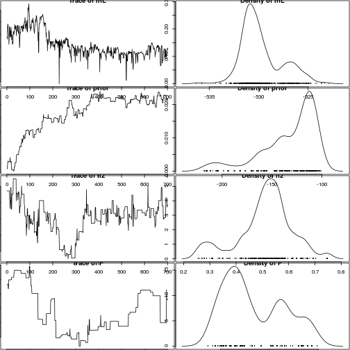

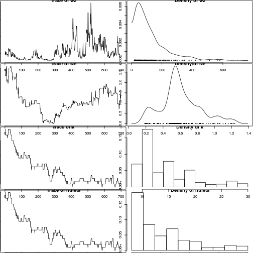

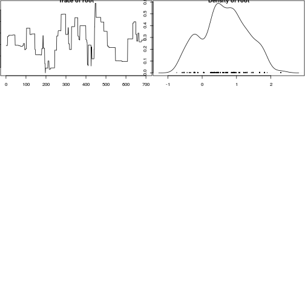

```r
plot(chainQG)
```

```r
pdf("../output/runs/modelQG/ModelQGHeatMap.pdf", height=20, width=8)
```

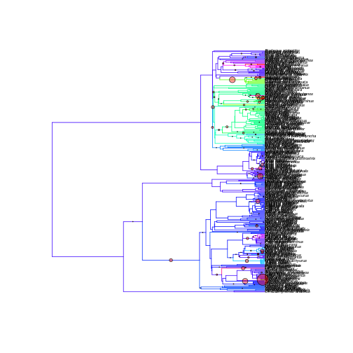

```r
#Posterior probabilities proportional to circle diameter:
plotSimmap.mcmc(chainQG, burnin=0.3, cex=0.5)
```

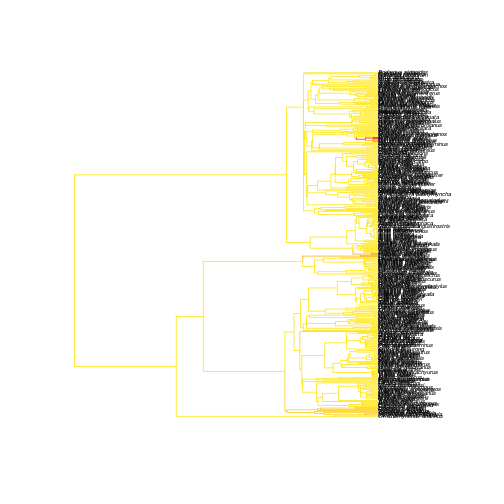

```r
#Branch color proportional to posterior mode value for theta
plotBranchHeatMap(QGtree, chainQG, variable="theta", burnin=0.3, cex=0.5, lwd=2)
```

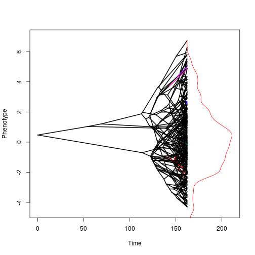

```r
#Phenogram with branches with posterior probabilities > 0.3 colored and a density plot of the posterior of all thetas:
phenogram.density(QGtree, dat, burnin=0.3, chainQG, pp.cutoff=0.3)
```

```r
dev.off()
```

# Model Comparison

Alternative parameterizations, shift locations, and priors can be compared using Bayes Factors. This requires estimation of the marginal likelihood, which can be difficult. bayou uses stepping-stone sampling to estimate the marginal likelihoods. To estimate marginal likelihoods, using the ‘$steppingstone’ function in the mcmc object. For this exercise, we will do a much shorter run than is recommended. If you have multiple cores available on your machine, you can make use of these to run the stepping stone analysis in parallel and conduct the analysis much faster.

```r
library(foreach)
library(doParallel)
registerDoParallel(cores=2)

# Choose the steps from the reference distribution to the posterior distribution, this should be 20-100 steps for a full analysis,
# but we will use only 5.Note that for each step, an MCMC chain must be run, meaning that this step could take substantially longer
# than the original analysis.

Bk <- qbeta(seq(0,1, length.out=5), 0.3,1)
ssOU <- mcmcOU$steppingstone(10000, chainOU, Bk, burnin=0.3, plot=FALSE)
ssBB <- mcmcBB$steppingstone(10000, chainBB, Bk, burnin=0.3, plot=FALSE)
ssQG <- mcmcQG$steppingstone(10000, chainQG, Bk, burnin=0.3, plot=FALSE)

mlnL <- c("OU"=ssOU$lnr, "BB"=ssBB$lnr, "QG"=ssQG$lnr)
```

# Allometric models

What if there is a known (or unknown) relationship between the trait of interest and another predictor variable? For example, we may be interested in a relationship between trait known to vary with body size, but consider the possibility that the relationship with body size itself varies over macroevolutionary time. Here, instead of having a single optimum that changes upon a regime shift, it is possible to have both the slope and intercept of the relationship change at once. bayou v2.0 allows you to include these additional predictors and test for shifts in the scaling between a trait and its predictors.

Well studied allometries such as the relationships between morphological variables (e.g. brain-body size) or metabolic rate and body size can be studied using this method. But let’s do a relationship from the species 360 database that is less explored, the evolution of body temperature.

```r
tdTb <- mutate(td, TbK = BodyTemperature + 273.15, lnGlucose = log(GLUCOSE),
                lnMass = log(Weight_1.82.2yearsage),
                  TbK.SD = BodyTemperature.SD,
                    N = BodyTemperature.N) %>%
                  dplyr::select(., TbK, TbK.SD, N, lnMass, lnGlucose) %>% filter(., !is.na(TbK), !is.na(lnGlucose),
                                                                                 is.finite(lnMass), TbK<320, !is.na(lnMass))

tdTb <- mutate(tdTb, ME=ifelse(N==1 | TbK.SD==0, mean(TbK.SD), TbK.SD/sqrt(N)))
tdTb
```

```
## $phy
##
## Phylogenetic tree with 204 tips and 203 internal nodes.
##
## Tip labels:
##  Ornithorhynchus_anatinus, Tachyglossus_aculeatus, Myrmecophaga_tridactyla, Tamandua_tetradactyla, Choloepus_didactylus, Tolypeutes_matacus, ...
##
## Rooted; includes branch lengths.
##
## $dat
## # A tibble: 204 x 6
##       TbK TbK.SD     N    lnMass lnGlucose        ME
##     <dbl>  <dbl> <int>     <dbl>     <dbl>     <dbl>
## 1  305.15    0.0     1 0.4134333  4.007333 0.9387255
## 2  305.15    0.0     1 1.3840418  4.430817 0.9387255
## 3  306.75    0.9    42 3.8950803  4.234107 0.1388730
## 4  307.55    0.9    30 1.7606127  4.543295 0.1643168
## 5  306.55    1.0    59 1.9942921  4.174387 0.1301889
## 6  306.15    0.7    29 0.2956502  4.262680 0.1299867
## 7  309.75    1.2   106 1.2490418  4.644391 0.1165543
## 8  309.15    0.8     4 6.7344727  4.488636 0.4000000
## 9  309.15    0.0     1 5.9380638  4.454347 0.9387255
## 10 310.45    0.9    64 3.4068481  4.700480 0.1125000
## # ... with 194 more rows
```

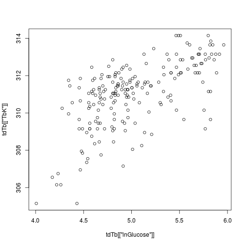

```r
#Note, I'm filtering out data with mass missing purely to make the dataset smaller and more tractable, you could
#run this analysis on the full dataset without any problem.

plot(tdTb[['lnGlucose']], tdTb[['TbK']])
```

Let’s create a separate table for the predictors, and scale them to a common scale.

```r
tree <- tdTb$phy
dat <- tdTb[['TbK']]
ME <- tdTb[['ME']]
pred <- mutate(tdTb$dat, lnGlu = scale(lnGlucose), lnM = scale(lnMass)) %>%  dplyr::select(., lnGlu, lnM)
lnGlu <- pred[1]
lnM <- pred[2]
```

We are going to test 3 models in this analysis: Global intercepts & slopes (11), Separate intercepts & global slope (N1), and separate intercepts & slopes (NN).

```r
prior.11 <- make.prior(tree, plot.prior = FALSE,
                           dists=list(dalpha="dhalfcauchy", dsig2="dhalfcauchy", dbeta_lnGlu="dnorm",
                                      dsb="fixed", dk="fixed", dtheta="dnorm"),
                           param=list(dbeta_lnGlu=list(mean=0, sd=1),
                                     dtheta=list(mean=mean(dat), sd=1.5*sd(dat))),
                           fixed=list(k=0, sb=numeric(0), loc=numeric(0))
)

prior.N1 <- make.prior(tree, plot.prior = FALSE,
                       dists=list(dalpha="dhalfcauchy", dsig2="dhalfcauchy", dbeta_lnGlu="dnorm",
                                  dsb="dsb", dk="cdpois", dtheta="dnorm"),
                       param=list(dbeta_lnGlu=list(mean=0, sd=1),
                                  dk=list(lambda=15, kmax=200),
                                  dsb=list(bmax=1, prob=1),
                                  dtheta=list(mean=mean(dat), sd=1.5*sd(dat)))
)


prior.NN <- make.prior(tree, plot.prior = FALSE,
                       dists=list(dalpha="dhalfcauchy", dsig2="dhalfcauchy", dbeta_lnGlu="dnorm",
                                  dsb="dsb", dk="cdpois", dtheta="dnorm"),
                       param=list(dbeta_lnGlu=list(mean=0, sd=1),
                                  dk=list(lambda=15, kmax=200),
                                  dsb=list(bmax=1, prob=1),
                                  dtheta=list(mean=mean(dat), sd=1.5*sd(dat)))
)

cache <- bayou:::.prepare.ou.univariate(tree, dat, SE=ME, pred=pred)
```

Manually set tuning parameters:

```r
D11 = list(alpha=1, sig2=1, beta_lnGlu=0.5, k=1, theta=0.5, slide=1)
DN1 = list(alpha=1, sig2=1, beta_lnGlu=0.5, k=1, theta=2, slide=1)
DNN = list(alpha=1, sig2=1, beta_lnGlu=1, k=c(1,1), theta=2, slide=1)

set.seed(1)
model.11 <- makeBayouModel(dat ~ lnGlu, rjpars = c(), cache=cache, prior=prior.11, D=D11)
model.N1 <- makeBayouModel(dat ~ lnGlu, rjpars = c("theta"), cache=cache, prior=prior.N1, D=DN1)
model.NN <- makeBayouModel(dat ~ lnGlu, rjpars = c("theta", "lnGlu"), cache=cache, prior=prior.NN, D=DNN)
```

Make MCMC objects:

```r
mcmc.11 <- bayou.makeMCMC(tree, dat, pred=lnGlu, SE=ME, model=model.11$model, prior=prior.11, startpar=model.11$startpar, new.dir="../output/runs/TbK_11/", outname="model11_r001", plot.freq=NULL)
mcmc.N1 <- bayou.makeMCMC(tree, dat, pred=lnGlu, SE=ME, model=model.N1$model, prior=prior.N1, startpar=model.N1$startpar, new.dir="../output/runs/TbK_N1/", outname="modelN1_r001", plot.freq=NULL)
mcmc.NN <- bayou.makeMCMC(tree, dat, pred=lnGlu, SE=ME, model=model.NN$model, prior=prior.NN, startpar=model.NN$startpar, new.dir="../output/runs/TbK_NN/", outname="modelNN_r001", plot.freq=NULL)

mcmc.11$run(10000)
```

```
## gen     lnL     prior   alpha   sig2    beta_ln rtheta  k       .alpha  .beta_l .sig2   .theta
## 1000    -345.40 -11.28  6.55    19.00   1.12    311.17  0       0.35    0.48    0.31    0.55
## 2000    -350.13 -10.96  4.24    16.23   0.94    310.87  0       0.40    0.49    0.36    0.53
## 3000    -345.26 -12.20  12.02   36.73   1.19    311.06  0       0.38    0.51    0.37    0.53
## 4000    -345.09 -11.57  9.18    26.48   1.05    311.03  0       0.36    0.51    0.36    0.53
## 5000    -345.56 -14.59  35.86   98.90   1.03    311.13  0       0.35    0.51    0.37    0.53
## 6000    -345.10 -12.41  14.89   42.15   1.12    311.03  0       0.34    0.52    0.36    0.53
## 7000    -346.51 -11.72  9.03    28.02   1.14    310.92  0       0.34    0.52    0.34    0.53
## 8000    -349.27 -10.86  2.97    11.97   1.01    311.18  0       0.35    0.52    0.34    0.53
## 9000    -345.56 -10.83  1.55    4.55    1.15    310.96  0       0.34    0.52    0.35    0.53
## 10000   -346.76 -11.54  6.88    24.52   1.15    310.97  0       0.33    0.52    0.35    0.52
```

```r
mcmc.N1$run(10000)
```

```
## gen     lnL     prior   alpha   sig2    beta_ln rtheta  k       .alpha  .beta_l birth.k D0.slid D1.slid death.k .sig2   .theta  U0.slid U1.slid U2.slid
## 1000    -290.09 -71.97  27.76   46.71   0.77    311.33  8       0.32    0.46    0.01    1.00    0.25    0.62    0.47    0.51    1.00    0.50    0.60
## 2000    -290.87 -60.43  26.77   43.78   0.79    311.56  6       0.34    0.49    0.00    1.00    0.18    0.54    0.46    0.50    1.00    0.27    0.41
## 3000    -286.58 -62.39  39.69   65.42   0.74    311.49  6       0.36    0.49    0.00    1.00    0.17    0.50    0.45    0.50    1.00    0.19    0.29
## 4000    -284.56 -69.27  54.81   89.90   0.92    311.61  7       0.37    0.46    0.00    1.00    0.17    0.47    0.40    0.49    1.00    0.13    0.26
## 5000    -272.84 -70.64  99.61   132.66  0.82    311.66  7       0.36    0.44    0.01    1.00    0.24    0.46    0.37    0.50    1.00    0.13    0.21
## 6000    -275.08 -58.37  70.43   98.53   0.95    311.49  5       0.36    0.44    0.01    1.00    0.23    0.38    0.38    0.49    1.00    0.12    0.20
## 7000    -271.84 -56.50  40.72   49.90   0.87    311.50  5       0.36    0.45    0.00    1.00    0.20    0.36    0.37    0.49    1.00    0.09    0.19
## 8000    -262.40 -66.16  24.91   24.89   0.90    311.42  7       0.37    0.46    0.01    1.00    0.18    0.34    0.38    0.48    1.00    0.09    0.17
## 9000    -262.28 -76.42  29.19   25.49   0.93    311.41  9       0.36    0.45    0.01    1.00    0.17    0.32    0.37    0.48    1.00    0.09    0.17
## 10000   -271.06 -74.60  10.90   11.88   0.86    311.38  9       0.37    0.44    0.01    0.99    0.18    0.33    0.37    0.49    1.00    0.10    0.16
```

```r
mcmc.NN$run(10000)
```

```
## gen     lnL     prior   alpha   sig2    beta_ln rtheta  k       .alpha  .beta_l birth.k D0.slid D1.slid death.k .sig2   .theta  U0.slid U1.slid U2.slid
## 1000    -279.23 -103.82 262.80  351.23  -0.89   313.08  10      0.36    0.75    0.00    1.00    0.33    1.00    0.49    0.58    1.00    0.75    0.29
## 2000    -272.00 -87.09  174.94  213.84  0.01    313.75  8       0.38    0.71    0.00    1.00    0.47    0.60    0.00    0.46    0.52    1.00    0.67    0.20
## 3000    -271.18 -81.28  201.72  225.67  1.35    310.07  7       0.37    0.67    0.00    1.00    0.36    0.50    0.00    0.44    0.48    1.00    0.50    0.13
## 4000    -272.40 -85.96  74.26   96.16   1.57    310.05  8       0.37    0.66    0.00    1.00    0.29    0.41    0.00    0.41    0.46    1.00    0.42    0.13
## 5000    -259.74 -96.72  63.07   64.04   1.87    310.10  10      0.36    0.67    0.01    1.00    0.28    0.40    0.00    0.38    0.47    1.00    0.43    0.16
## 6000    -263.81 -80.90  25.50   35.20   1.53    309.99  8       0.36    0.66    0.00    1.00    0.25    0.37    0.00    0.39    0.46    1.00    0.45    0.14
## 7000    -263.78 -66.77  33.24   35.87   1.76    309.96  6       0.36    0.65    0.00    1.00    0.24    0.38    0.00    0.39    0.44    1.00    0.43    0.11
## 8000    -260.38 -65.99  16.81   19.87   1.46    309.77  6       0.37    0.63    0.00    1.00    0.22    0.36    0.00    0.39    0.44    1.00    0.43    0.11
## 9000    -260.11 -65.40  21.66   20.89   1.58    309.94  6       0.37    0.63    0.00    1.00    0.21    0.33    0.00    0.38    0.43    1.00    0.39    0.10
## 10000   -260.51 -66.87  28.24   31.20   1.36    309.85  6       0.36    0.62    0.00    1.00    0.18    0.31    0.00    0.39    0.41    1.00    0.33    0.09
```

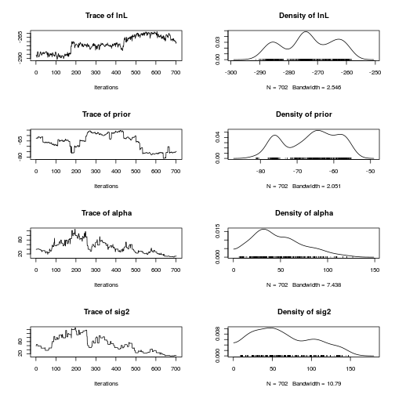

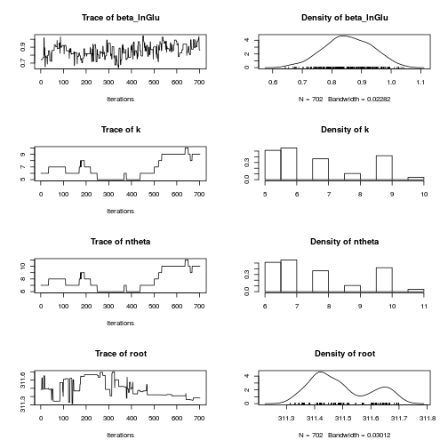

```r
chain.11 <- mcmc.11$load()
chain.N1 <- mcmc.N1$load()
chain.NN <- mcmc.NN$load()

chain.11 <- set.burnin(chain.11, 0.3)
chain.N1 <- set.burnin(chain.N1, 0.3)
chain.NN <- set.burnin(chain.NN, 0.3)
plot(chain.N1)
```

```r
summary(chain.N1)
```

```
## bayou MCMC chain: 10000 generations
## 1001 samples, first 300 samples discarded as burnin
```

```
##
##
## Summary statistics for parameters:
##                    Mean          SD    Naive SE Time-series SE
## lnL        -273.2037183  8.90952387 0.336268309    6.540997400
## prior       -66.2740356  7.17565710 0.270827725    4.159965117
## alpha        47.7462454 26.54368189 1.001826714   12.571437694
## sig2         64.8508642 37.74674734 1.424659171   18.245609309
## beta_lnGlu    0.8540921  0.07983316 0.003013108    0.009693164
## k             6.7421652  1.52034792 0.057381834    1.002151876
## ntheta        7.7421652  1.52034792 0.057381834    1.002151876
## root.theta  311.4920183  0.10540348 0.003978198    0.036670557
## all theta   309.7269909  1.72540774          NA             NA
##            Effective Size  HPD95Lower   HPD95Upper
## lnL              1.855329 -287.599973 -259.1074367
## prior            2.975391  -77.215631  -55.8054286
## alpha            4.458127    7.731938   99.6100147
## sig2             4.279986    9.490945  134.4947585
## beta_lnGlu      67.832139    0.689994    0.9952919
## k                2.301542    5.000000    9.0000000
## ntheta           2.301542    6.000000   10.0000000
## root.theta       8.261804  311.344212  311.6647176
## all theta              NA  309.726991    1.7254077
##
##
## Branches with posterior probabilities higher than 0.1:
##            pp magnitude.of.theta2 naive.SE.of.theta2 rel.location
## 395 1.0000000            308.2114        0.016130180   0.27231803
## 400 1.0000000            309.4691        0.009356075   1.00196587
## 403 1.0000000            307.2937        0.028162053  24.87475842
## 243 0.7521368            309.9237        0.010300628   0.05984296
## 212 0.5954416            308.0822        0.025505725   1.14405920
## 213 0.4045584            308.8054        0.022104689  15.31619403
## 359 0.3148148            312.5572        0.014863175   0.02681052
## 233 0.2649573            309.9401        0.025891527   5.10904823
## 92  0.2122507            311.4678        0.021182486   0.13037135
## 45  0.1994302            311.5790        0.083311633   6.36993011
## 337 0.1182336            311.7084        0.026591777   0.18962237
```

```r
pdf("../output/runs/TbK_N1/ShiftSummaries_N1.pdf", height=8, width=8)
```

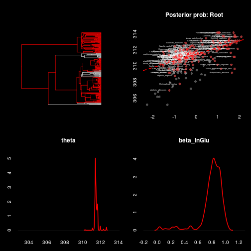

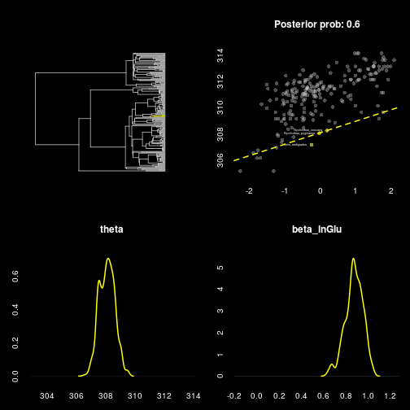

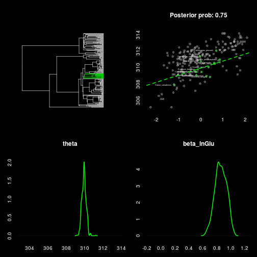

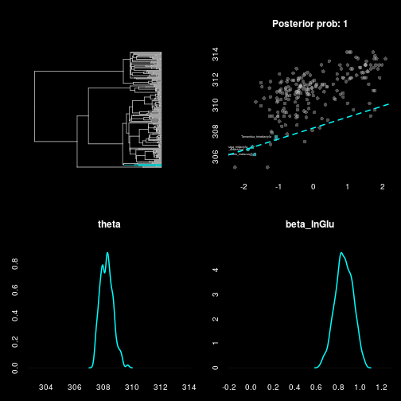

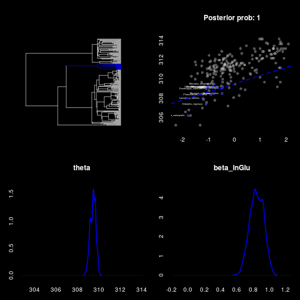

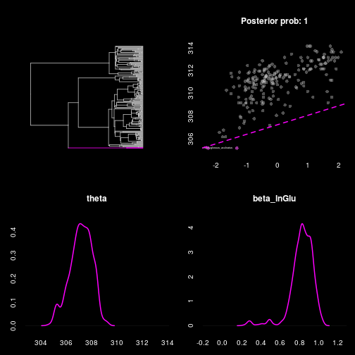

```r
shiftsumsN1 <- shiftSummaries(chain.N1, mcmc.N1, pp.cutoff=0.5)
plotShiftSummaries(shiftsumsN1, lwd=2)
```

```r
dev.off()
```

```r
pdf("../output/runs/TbK_NN/ShiftSummaries_NN.pdf", height=8, width=8)
```

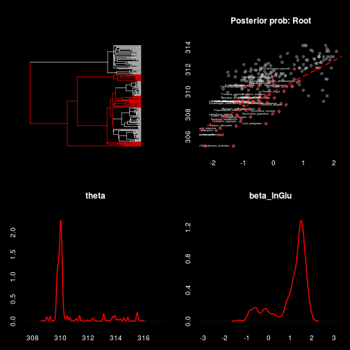

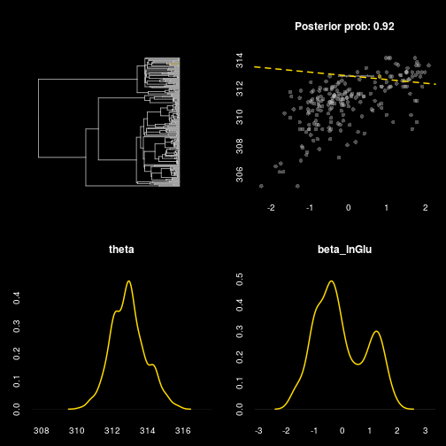

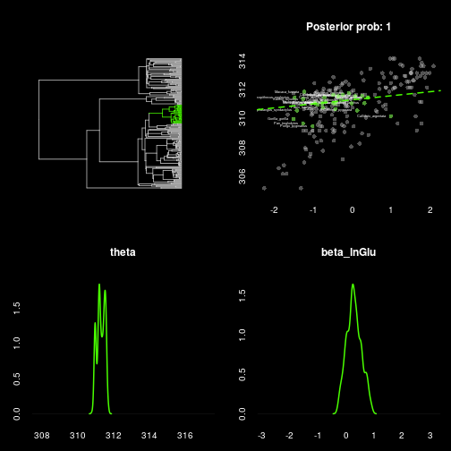

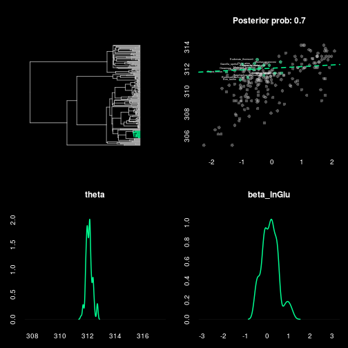

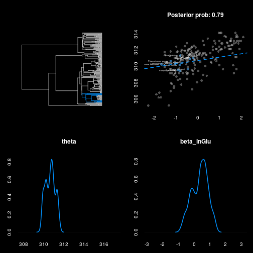

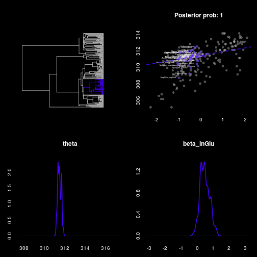

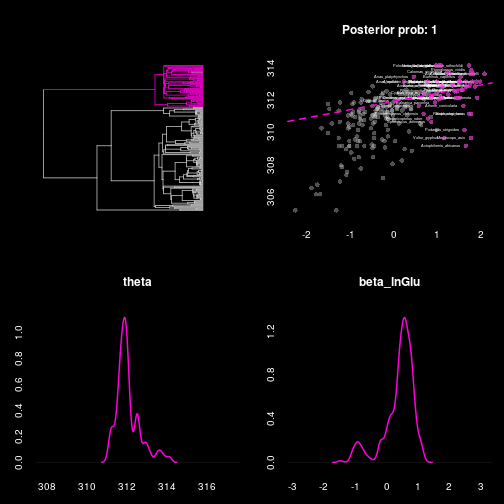

```r
shiftsumsNN <- shiftSummaries(chain.NN, mcmc.NN, pp.cutoff=0.5)
plotShiftSummaries(shiftsumsNN, lwd=2)
```

```r
dev.off()
```

We can do model comparison as well with allometric models. Often, these reversible jump models can be hard to get to converge. It may be wise to fix the shifts with high posterior probabilities and do model selection on these models, rather than doing the fully reversible-jump analysis.

```r
# Choose the steps from the reference distribution to the posterior distribution, this should be 20-100 steps for a full analysis,
# but we will use only 5.Note that for each step, an MCMC chain must be run, meaning that this step could take substantially longer
# than the original analysis.
Bk <- qbeta(seq(0,1, length.out=5), 0.3,1)
registerDoParallel(cores=2)
set.seed(1)
ss.11 <- mcmc.11$steppingstone(10000, chain.11, Bk, burnin=0.3)
```

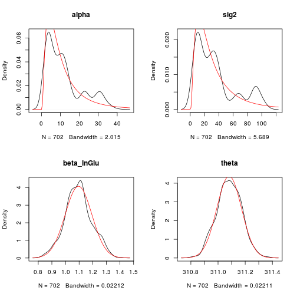

```r
ss.N1 <- mcmc.N1$steppingstone(10000, chain.N1, Bk, burnin=0.3)
ss.NN <- mcmc.NN$steppingstone(10000, chain.NN, Bk, burnin=0.3)
```

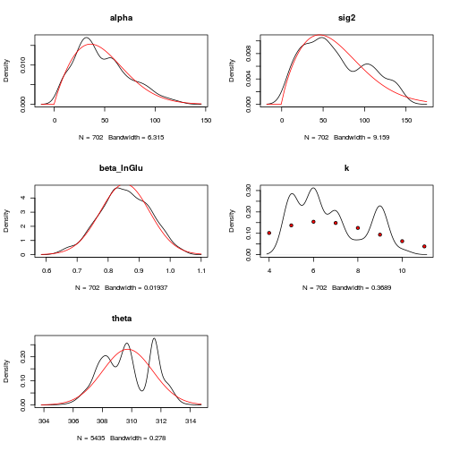

```r
ss.TbK <- list(ss.11, ss.N1, ss.NN)
sapply(ss.TbK, function(x) x$lnr)
```

```
## [1] -354.5425 -334.7981 -314.9937
```

[figure not shown]

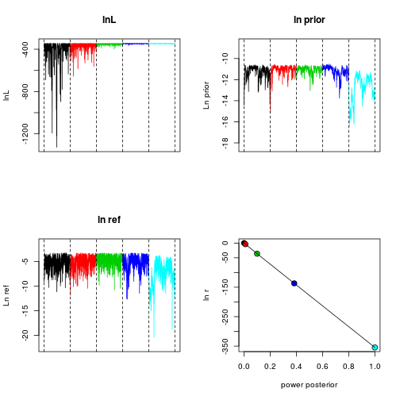

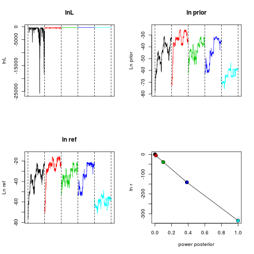

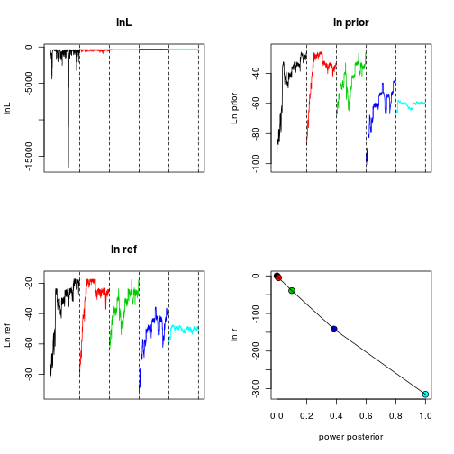

```r
sapply(ss.TbK, plot)
```